# experiment_5_scaling

Mike Krähenbühl

2025-04-03

## Data Preparation

Read raw data:

```r
library(ncdf4)

# read the file "enso_son.nc"  without raster stored in the same directory

enso <- nc_open("data/enso_son.nc")
enso_y <- ncvar_get(enso, "Year")
enso_raw <- ncvar_get(enso, "enso")

# print the timeseries of enso
# plot(enso_y, enso_v, type = "l", xlab = "Year", ylab = "ENSO")


# read the file "iod_son.nc" stored in the same directory

iod <- nc_open("data/iod_son.nc")
iod_y <- ncvar_get(iod, "Year")
iod_raw <- ncvar_get(iod, "iod")

# print the timeseries of iod
# plot(iod_y, iod_v, type = "l", xlab = "Year", ylab = "IOD")


# read the file "precip_au_son.nc" stored in the same directory

au <- nc_open("data/precip_au_son.nc")
au_y <- ncvar_get(au, "year")
au_raw <- ncvar_get(au, "precip")
# hist(au_raw)
```

Standardize data:

```r
# standardize (zero to mean, unit variance)
ENSO_std <- (enso_raw - mean(enso_raw))/sd(enso_raw)
IOD_std <- (iod_raw - mean(iod_raw))/sd(iod_raw)
AU_std <- (au_raw - mean(au_raw))/sd(au_raw)
```

Detrend standardized data:

```r
ENSO_detrended <- residuals(lm(ENSO_std ~ enso_y))
IOD_detrended <- residuals(lm(IOD_std ~ iod_y))
AU_detrended <- residuals(lm(AU_std ~ au_y))
```

Plot timeseries:

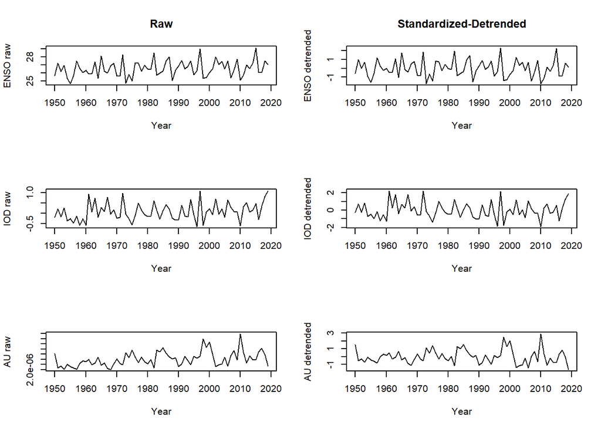

```r
# plot raw timeseries
par(mfrow=c(3,2))
plot(enso_y, enso_raw, type = "l", xlab = "Year", ylab = "ENSO raw",
     main = "Raw")
plot(enso_y, ENSO_detrended, type = "l", xlab = "Year", ylab = "ENSO detrended",
     main = "Standardized-Detrended")

plot(iod_y, iod_raw, type = "l", xlab = "Year", ylab = "IOD raw")
plot(iod_y, IOD_detrended, type = "l", xlab = "Year", ylab = "IOD detrended")

plot(au_y, au_raw, type = "l", xlab = "Year", ylab = "AU raw")
plot(au_y, AU_detrended, type = "l", xlab = "Year", ylab = "AU detrended")
```

Plot histograms:

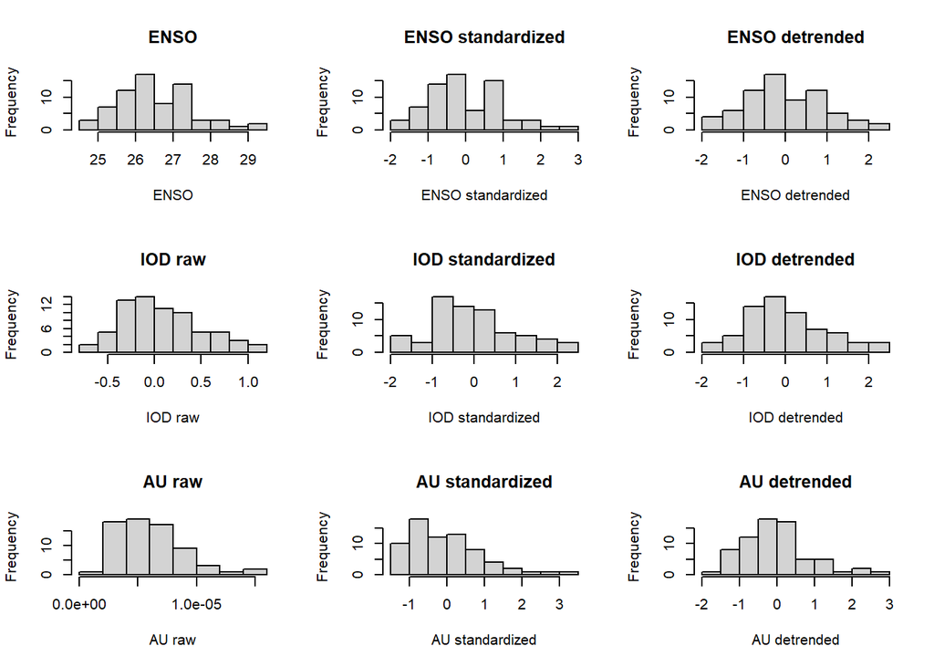

```r
# 3 histograms of the raw data
par(mfrow=c(3,3))
hist(enso_raw, main = "ENSO", xlab = "ENSO")
hist(ENSO_std, main = "ENSO standardized", xlab = "ENSO standardized")
hist(ENSO_detrended, main = "ENSO detrended", xlab = "ENSO detrended")

hist(iod_raw, main = "IOD raw", xlab = "IOD raw")
hist(IOD_std, main = "IOD standardized", xlab = "IOD standardized")
hist(IOD_detrended, main = "IOD detrended", xlab = "IOD detrended")

hist(au_raw, main = "AU raw", xlab = "AU raw")
hist(AU_std, main = "AU standardized", xlab = "AU standardized")
hist(AU_detrended, main = "AU detrended", xlab = "AU detrended")
```

## Impact of Scaling (real data)

Scaling only changes the x-Axis values, shape and value of density remains unchanged.

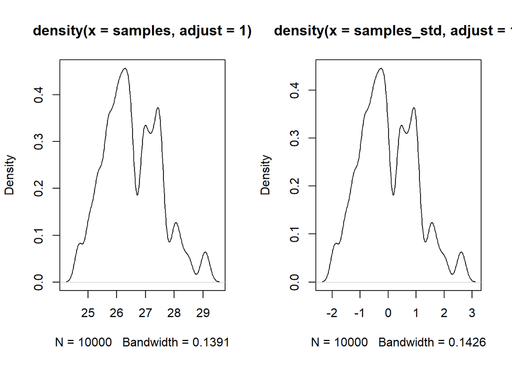

```r
# Set seed for reproducibility
set.seed(123)

samples <- sample(enso_raw, replace = TRUE, size = 10000)
samples_std <- (samples- mean(samples))/sd(samples)

par(mfrow=c(1,2))
plot(density(samples, adjust = 1))
plot(density(samples_std, adjust = 1))
```

We want to model the impact of ENSO and IOD on AU. The model is given by:

$\mathrm{F}(AU \mid ENSO, IOD) = {F_z}(h(AU) + \beta_1 ENSO + \beta_2 IOD)$

These are the scales of the raw variables:

```r
# ENSO
sd(enso_raw)
```

```
## [1] 0.9968555
```

```r
# IOD
sd(iod_raw)
```

```
## [1] 0.4280147
```

```r
# AU
sd(au_raw)
```

```
## [1] 2.855879e-06
```

Standard deviation of ENSO is almost 1, therefore scaling might not have a big effect (only a shift). IOD is 0.42 and AU is very small.

Fit a Colr model with the raw data:

```r
library(tram)
len_theta <- 20

## only raw data
fit_raw = Colr(au_raw ~ enso_raw + iod_raw, order=len_theta)
coef(fit_raw)
```

```
##   enso_raw    iod_raw
## 0.68235266 0.06322657
```

Fit a Colr model with the standardized data:

```r
## only standardized data
fit_std = Colr(AU_std ~ ENSO_std + IOD_std, order=len_theta)
coef(fit_std)
```

```
##     ENSO_std      IOD_std
##  0.749442651 -0.007374579
```

Comparison of baseline Transformation functions:

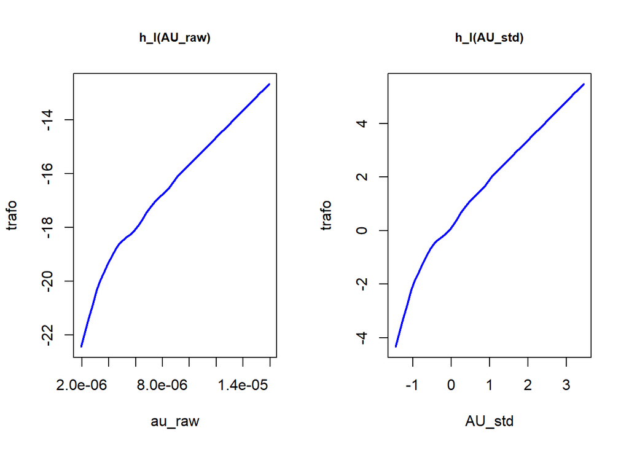

```r
par(mfrow=c(1,2))
temp = model.frame(fit_raw)[1:2,-1, drop=FALSE]
plot(fit_raw, which = 'baseline only', newdata = temp, lwd=2, col='blue',
     main='h_I(AU_raw)', cex.main=0.8)


temp = model.frame(fit_std)[1:2,-1, drop=FALSE]
plot(fit_std, which = 'baseline only', newdata = temp, lwd=2, col='blue',
     main='h_I(AU_std)', cex.main=0.8)
```

In both plots, the x-axis scale changes because the response scale is changed. And also the y-axis (latent scale) is changed, because the scale of the predictors is changed. For example, the raw ENSO is on average around value 26, and when standardized around 0, this changes the y-axis intercept. The shape of the transformation function is the same.

### Mixed scales

All raw model:

$\mathrm{F}(AU_{raw} \mid ENSO_{raw}, IOD_{raw}) = {F_z}(h(AU{raw}) + \beta_1 ENSO_{raw} + \beta_2IOD_{raw})$

```r
fit_all_raw = Colr(au_raw ~ enso_raw + iod_raw, order=len_theta)
round(coef(fit_all_raw), 4)
```

```
## enso_raw  iod_raw
##   0.6824   0.0632
```

Interpretation: $\beta_1$ is the additive change in log-odds for AU for a 1 unit change in ENSO, when holding IOD constant. The reference level for ENSO is 0.

Example: for ENSO=24, the log-odds of AU is $h(AU) + \beta_1 * 24 + \beta_2 * IOD$.

Standardized Outcome, raw predictors:

$\mathrm{F}(AU_{std} \mid ENSO_{raw}, IOD_{raw}) = {F_z}(h(AU{std}) + \beta_1 ENSO_{raw} + \beta_2IOD_{raw})$

```r
fit_AU_std = Colr(AU_std ~ enso_raw + iod_raw, order=len_theta)
round(coef(fit_AU_std), 4)
```

```
## enso_raw  iod_raw
##   0.7481  -0.0097
```

All standardized model:

$\mathrm{F}(AU_{\text{std}} \mid ENSO_{\text{std}}, IOD_{\text{std}}) = F_z\left(h(AU_{\text{std}}) + \beta_1 * \frac{ENSO - \text{mean}(ENSO)}{\text{sd}(ENSO)} + \beta_2 * \frac{IOD - \text{mean}(IOD)}{\text{sd}(IOD)}\right)$

```
## [1] "Mean ENSO: 26.55   Sd ENSO: 1"
```

```
## [1] "Mean IOD: 0.08   Sd IOD: 0.43"
```

```r
fit_all_std = Colr(AU_std ~ ENSO_std + IOD_std, order=len_theta)
round(coef(fit_all_std), 4)
```

```
## ENSO_std  IOD_std
##   0.7494  -0.0074
```

Interpretation: $\beta_1$ is the additive change in log-odds for AU for a 1 unit change in standardized ENSO (in other words, for a 1 standard deviation change of ENSO), when holding IOD constant. The reference level for ENSO is 26.55 (mean of ENSO).

Example: for ENSO=26.55, the log-odds of AU is $h(AU) + \beta_1 * (26.55-26.55)/1 + \beta_2 * IOD = h(AU) + 0 + \beta_2 * IOD$.

AU raw, predictors standardized:

$\mathrm{F}(AU_{\text{raw}} \mid ENSO_{\text{std}}, IOD_{\text{std}}) = F_z\left(h(AU_{\text{raw}}) + \beta_1 * \frac{ENSO - \text{mean}(ENSO)}{\text{sd}(ENSO)} + \beta_2 * \frac{IOD - \text{mean}(IOD)}{\text{sd}(IOD)}\right)$

```r
fit_AU_raw = Colr(au_raw ~ ENSO_std + IOD_std, order=len_theta)
round(coef(fit_AU_raw), 4)
```

```
## ENSO_std  IOD_std
##   0.7491  -0.0075
```

The coefficients $\beta_1$ and $\beta_2$ are the same as in the previous model with the standardized outcome. This means, that when the predictors are standardized, it does not matter, if the outcome is standardized or not.

Interpretation: same as in the all standardized model above.

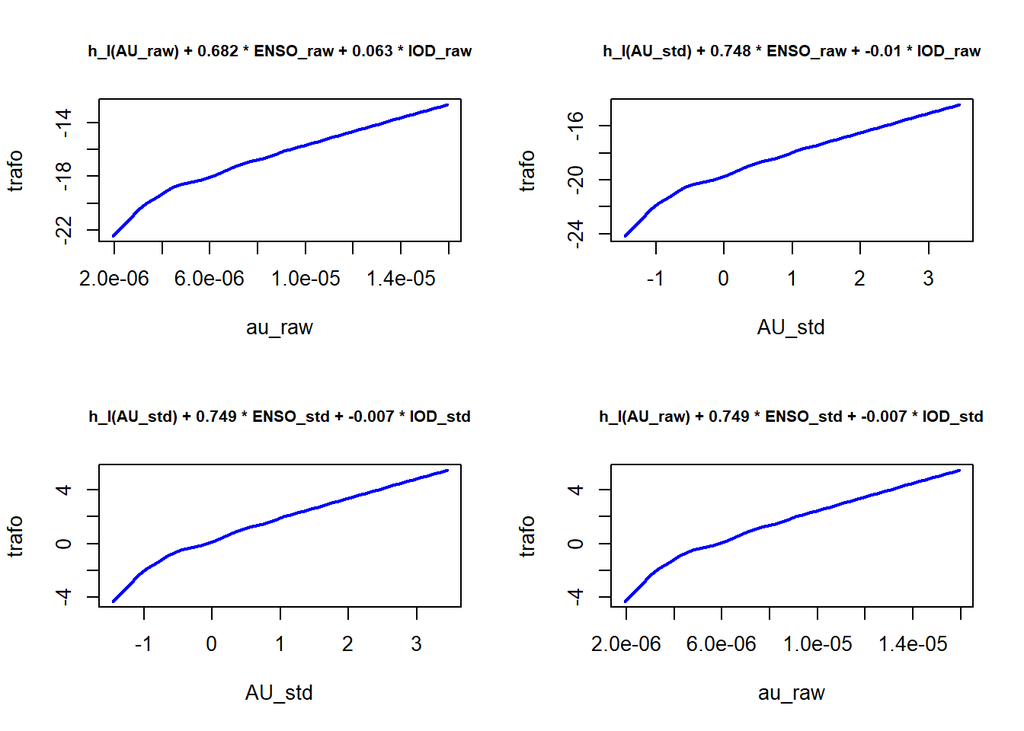

```r
par(mfrow = c(2,2))

temp = model.frame(fit_all_raw)[1:2,-1, drop=FALSE]
plot(fit_all_raw, which = 'baseline only', newdata = temp, lwd=2, col='blue',
     main=paste0("h_I(AU_raw) + ", round(coef(fit_all_raw)[1], 3), " * ENSO_raw + " , round(coef(fit_all_raw)[2], 3), " * IOD_raw"), cex.main=0.8)

temp = model.frame(fit_AU_std)[1:2,-1, drop=FALSE]
plot(fit_AU_std, which = 'baseline only', newdata = temp, lwd=2, col='blue',
     main=paste0("h_I(AU_std) + ", round(coef(fit_AU_std)[1], 3), " * ENSO_raw + " , round(coef(fit_AU_std)[2], 3), " * IOD_raw"), cex.main=0.8)

temp = model.frame(fit_all_std)[1:2,-1, drop=FALSE]
plot(fit_all_std, which = 'baseline only', newdata = temp, lwd=2, col='blue',
     main=paste0("h_I(AU_std) + ", round(coef(fit_all_std)[1], 3), " * ENSO_std + " , round(coef(fit_all_std)[2], 3), " * IOD_std"), cex.main=0.8)

temp = model.frame(fit_AU_raw)[1:2,-1, drop=FALSE]
plot(fit_AU_raw, which = 'baseline only', newdata = temp, lwd=2, col='blue',
     main=paste0("h_I(AU_raw) + ", round(coef(fit_AU_raw)[1], 3), " * ENSO_std + " , round(coef(fit_AU_raw)[2], 3), " * IOD_std"), cex.main=0.8)
```

Interpretation:

- When the predictors are standardized, it does not matter if we standardize the outcome or not. The coefficients are the same. The reason is, that only scale of the x-axis is changed.

AU = IOD

```r
coef(Colr(au_raw ~iod_raw, order=len_theta))
```

```
##  iod_raw
## 0.889924
```

```r
coef(Colr(AU_std ~iod_raw, order=len_theta))
```

```
##   iod_raw
## 0.8895465
```

```r
coef(Colr(AU_std ~IOD_std, order=len_theta))
```

```
##   IOD_std
## 0.3807749
```

```r
coef(Colr(au_raw ~IOD_std, order=len_theta))
```

```
##   IOD_std
## 0.3810426
```

AU = ENSO

```r
coef(Colr(au_raw ~ enso_raw, order=len_theta))
```

```
##  enso_raw
## 0.3450753
```

```r
coef(Colr(AU_std ~ enso_raw, order=len_theta))
```

```
##  enso_raw
## 0.6655537
```

```r
coef(Colr(AU_std ~ ENSO_std, order=len_theta))
```

```
## ENSO_std
## 0.745476
```

```r
coef(Colr(au_raw ~ ENSO_std, order=len_theta))
```

```
##  ENSO_std
## 0.7513855
```

As we can see, when enso is standardized, it does not matter much, if the outcome (AU) is standardized or not. The reason is that not the raw outcome is modelled but instead the log-odds of the outcome, which is scale invariant. Surprisingly, if raw Enso is taken, then the coefficients differ for raw or standardized Outcome. Enso has mean at 26 with standard deviation of around 1. Therefore, the reference point is Enso=0 and the coefficient indicates the change in log-odds for a 1 unit Enso increase. But because the mean is around 26, this is not a good reference point. I assume this is the reason why the first 2 coeffs differ.

AU = ENSO - mean(ENSO)

```r
enso_0mean <- enso_raw - mean(enso_raw)
coef(Colr(au_raw ~ enso_0mean, order=len_theta))
```

```
## enso_0mean
##  0.7472076
```

```r
coef(Colr(AU_std ~ enso_0mean, order=len_theta))
```

```
## enso_0mean
##    0.74744
```

```r
coef(Colr(AU_std ~ ENSO_std, order=len_theta))
```

```
## ENSO_std
## 0.745476
```

```r
coef(Colr(au_raw ~ ENSO_std, order=len_theta))
```

```
##  ENSO_std
## 0.7513855
```

When we use the same example as before, but subtract the mean of enso, we get the same coefficients as when using the standardized enso. This means that the reference point is now at mean(enso) and not at 0 anymore. I assume that this makes the estimated coefficients more reliable. -> but keep in mind that changing the predictor also changes the trafo.

IOD = ENSO

```r
iod_sc <- iod_raw/sd(iod_raw)

coef(fit31 <- Colr(iod_raw ~ enso_raw, order=len_theta))
```

```
##  enso_raw
## -1.327031
```

```r
coef(fit32 <- Colr(IOD_std ~ enso_raw, order=len_theta))
```

```
##  enso_raw
## -1.203324
```

```r
# coef(fit32 <- Colr(iod_sc ~ enso_raw, order=len_theta))  # when only scaling IOD, same as raw!

coef(fit33 <- Colr(IOD_std ~ ENSO_std, order=len_theta))
```

```
##  ENSO_std
## -1.323209
```

```r
coef(fit34 <- Colr(iod_raw ~ ENSO_std, order=len_theta))
```

```
##  ENSO_std
## -1.323099
```

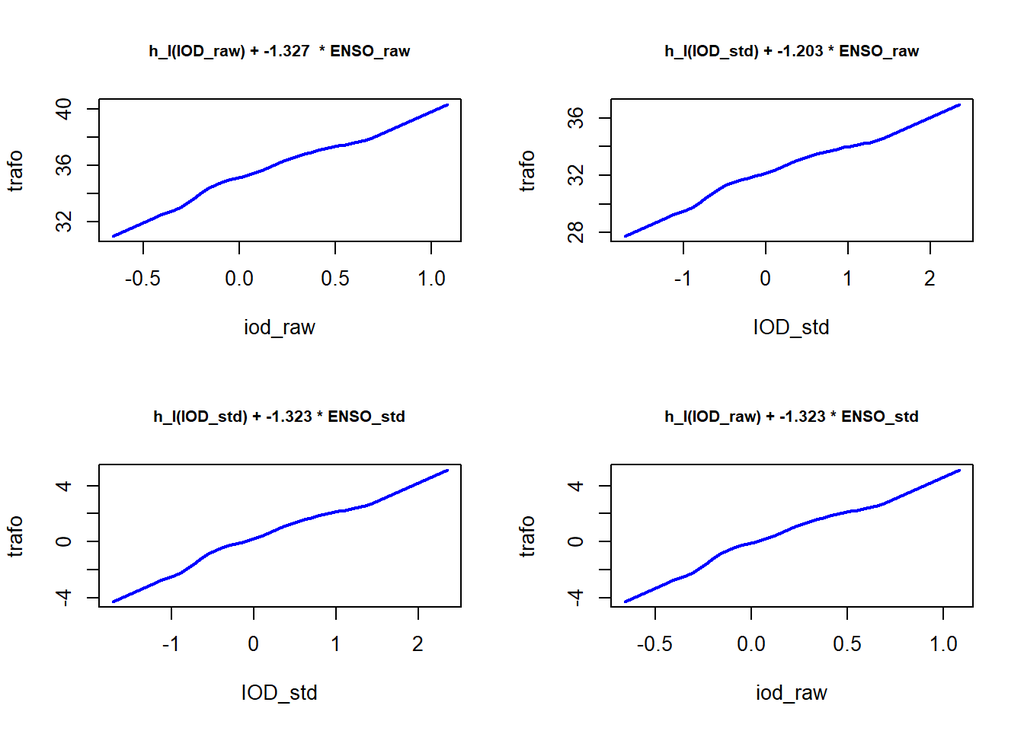

```r
par(mfrow = c(2,2))

temp = model.frame(fit31)[1:2,-1, drop=FALSE]
plot(fit31, which = 'baseline only', newdata = temp, lwd=2, col='blue',
     main=paste0("h_I(IOD_raw) + ", round(coef(fit31)[1], 3), "  * ENSO_raw"), cex.main=0.8)

temp = model.frame(fit32)[1:2,-1, drop=FALSE]
plot(fit32, which = 'baseline only', newdata = temp, lwd=2, col='blue',
     main=paste0("h_I(IOD_std) + ", round(coef(fit32)[1], 3),  " * ENSO_raw"), cex.main=0.8)

temp = model.frame(fit33)[1:2,-1, drop=FALSE]
plot(fit33, which = 'baseline only', newdata = temp, lwd=2, col='blue',
     main=paste0("h_I(IOD_std) + ", round(coef(fit33)[1], 3),  " * ENSO_std"), cex.main=0.8)

temp = model.frame(fit34)[1:2,-1, drop=FALSE]
plot(fit34, which = 'baseline only', newdata = temp, lwd=2, col='blue',
     main=paste0("h_I(IOD_raw) + ", round(coef(fit34)[1], 3), " * ENSO_std"), cex.main=0.8)
```

```r
summary(iod_raw)
```

```
##     Min.  1st Qu.   Median     Mean  3rd Qu.     Max.
## -0.65786 -0.20857  0.05794  0.07765  0.31247  1.08397
```

```r
summary(au_raw)
```

```
##      Min.   1st Qu.    Median      Mean   3rd Qu.      Max.
## 1.934e-06 3.945e-06 5.780e-06 6.095e-06 7.462e-06 1.594e-05
```

Log-odds of raw IOD:

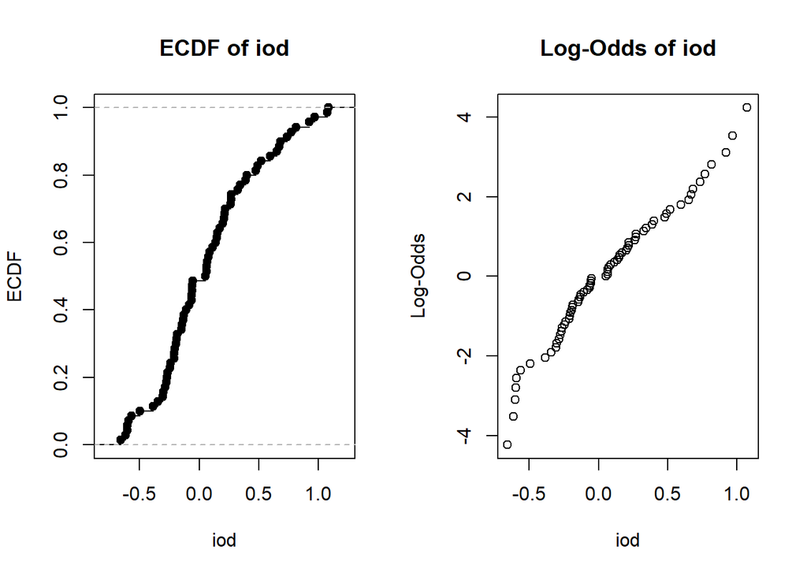

```r
par(mfrow=c(1,2))
# ecdf of AU
ecdf_iod <- ecdf(iod_raw)
plot(ecdf_iod, main = "ECDF of iod", xlab = "iod", ylab = "ECDF")

# log-odds of iod
log_odds_iod <- log(ecdf_iod(iod_raw) / (1 - ecdf_iod(iod_raw)))
plot(iod_raw, log_odds_iod, main = "Log-Odds of iod", xlab = "iod", ylab = "Log-Odds")
```

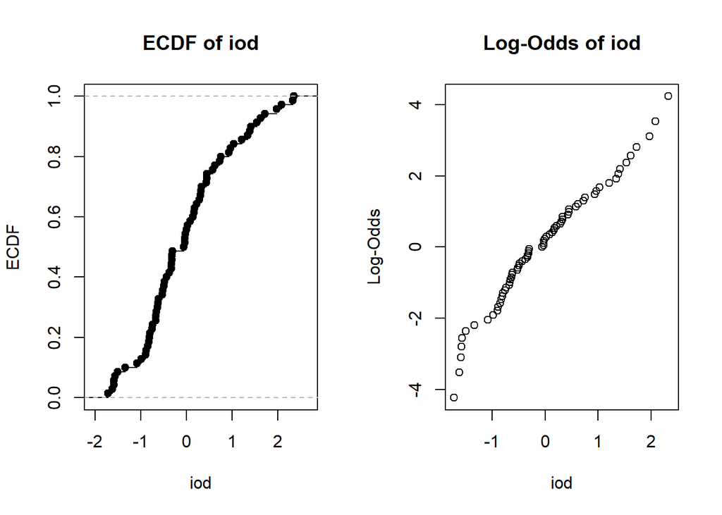

```r
par(mfrow=c(1,2))

# ecdf of AU
ecdf_iod_std <- ecdf(IOD_std)
plot(ecdf_iod_std, main = "ECDF of iod", xlab = "iod", ylab = "ECDF")

# log-odds of iod
log_odds_iod_std <- log(ecdf_iod_std(IOD_std) / (1 - ecdf_iod_std(IOD_std)))
plot(IOD_std, log_odds_iod_std, main = "Log-Odds of iod", xlab = "iod", ylab = "Log-Odds")
```

The log-odds of iod and iod_std are the same, because log-odds only depend on the shape of the ECDF and are therefore not affected by scaling.

```r
log_odds_iod_std == log_odds_iod
```

```
##  [1] TRUE TRUE TRUE TRUE TRUE TRUE TRUE TRUE TRUE TRUE TRUE TRUE TRUE TRUE TRUE
## [16] TRUE TRUE TRUE TRUE TRUE TRUE TRUE TRUE TRUE TRUE TRUE TRUE TRUE TRUE TRUE
## [31] TRUE TRUE TRUE TRUE TRUE TRUE TRUE TRUE TRUE TRUE TRUE TRUE TRUE TRUE TRUE
## [46] TRUE TRUE TRUE TRUE TRUE TRUE TRUE TRUE TRUE TRUE TRUE TRUE TRUE TRUE TRUE
## [61] TRUE TRUE TRUE TRUE TRUE TRUE TRUE TRUE TRUE TRUE
```

```r
Colr(IOD_std ~ ENSO_std, order=len_theta)
```

```
##
##   Continuous Outcome Logistic Regression
##
## Call:
## Colr(formula = IOD_std ~ ENSO_std, order = len_theta)
##
## Coefficients:
##  ENSO_std
## -1.323209
##
## Log-Likelihood:
##  -78.26331 (df = 22)
```

```r
Colr(iod_raw ~ ENSO_std, order=len_theta)
```

```
##
##   Continuous Outcome Logistic Regression
##
## Call:
## Colr(formula = iod_raw ~ ENSO_std, order = len_theta)
##
## Coefficients:
##  ENSO_std
## -1.323099
##
## Log-Likelihood:
##  -18.86146 (df = 22)
```

```r
Colr(IOD_std ~ enso_raw, order=len_theta)
```

```
##
##   Continuous Outcome Logistic Regression
##
## Call:
## Colr(formula = IOD_std ~ enso_raw, order = len_theta)
##
## Coefficients:
##  enso_raw
## -1.203324
##
## Log-Likelihood:
##  -78.38786 (df = 22)
```

```r
Colr(iod_raw ~ enso_raw, order=len_theta)
```

```
##
##   Continuous Outcome Logistic Regression
##
## Call:
## Colr(formula = iod_raw ~ enso_raw, order = len_theta)
##
## Coefficients:
##  enso_raw
## -1.327031
##
## Log-Likelihood:
##  -18.86146 (df = 22)
```

Log-odds of raw AU:

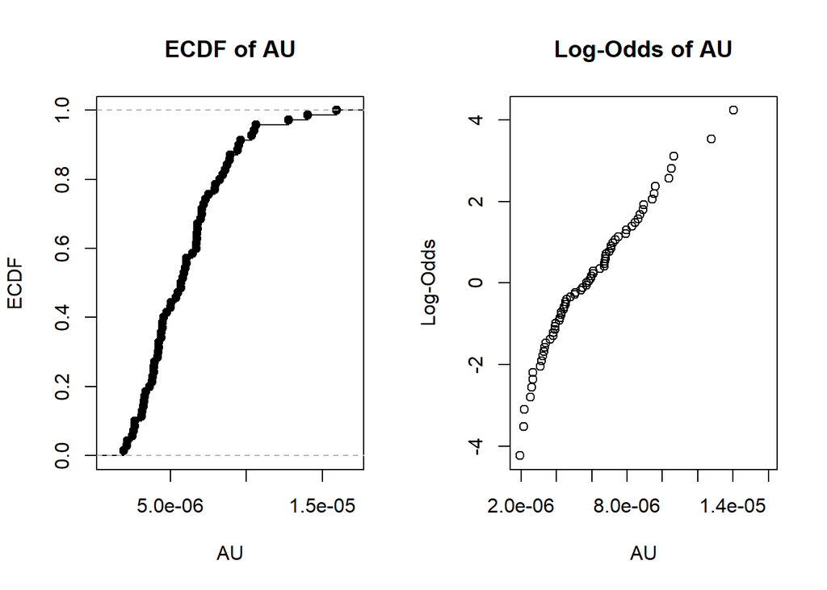

```r
par(mfrow=c(1,2))
# ecdf of AU
ecdf_AU <- ecdf(au_raw)
plot(ecdf_AU, main = "ECDF of AU", xlab = "AU", ylab = "ECDF")

# log-odds of AU
log_odds_AU <- log(ecdf_AU(au_raw) / (1 - ecdf_AU(au_raw)))
plot(au_raw, log_odds_AU, main = "Log-Odds of AU", xlab = "AU", ylab = "Log-Odds")
```

Log-Odds of standardized AU:

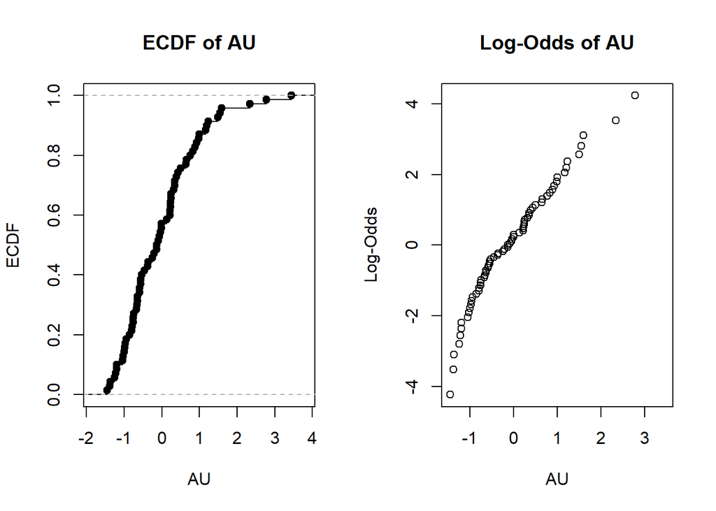

```r
par(mfrow=c(1,2))

# ecdf of AU
ecdf_AU_std <- ecdf(AU_std)
plot(ecdf_AU_std, main = "ECDF of AU", xlab = "AU", ylab = "ECDF")

# log-odds of AU
log_odds_AU_std <- log(ecdf_AU_std(AU_std) / (1 - ecdf_AU_std(AU_std)))
plot(AU_std, log_odds_AU_std, main = "Log-Odds of AU", xlab = "AU", ylab = "Log-Odds")
```

The log-odds of AU and AU_std are the same, because log-odds only depend on the shape of the ECDF and are therefore not affected by scaling.

```r
log_odds_AU_std == log_odds_AU
```

```
##  [1] TRUE TRUE TRUE TRUE TRUE TRUE TRUE TRUE TRUE TRUE TRUE TRUE TRUE TRUE TRUE
## [16] TRUE TRUE TRUE TRUE TRUE TRUE TRUE TRUE TRUE TRUE TRUE TRUE TRUE TRUE TRUE
## [31] TRUE TRUE TRUE TRUE TRUE TRUE TRUE TRUE TRUE TRUE TRUE TRUE TRUE TRUE TRUE
## [46] TRUE TRUE TRUE TRUE TRUE TRUE TRUE TRUE TRUE TRUE TRUE TRUE TRUE TRUE TRUE
## [61] TRUE TRUE TRUE TRUE TRUE TRUE TRUE TRUE TRUE TRUE
```

## Impact of Scaling (simulated)

### Simulate and scale for Linear regression

```r
len_theta <- 20

# Simulate and scale for Linear Regression

x1 <- runif(1000, 0, 50)
y <- 2*x1 + rnorm(1000, 0, 5)

par(mfrow=c(1,2))
plot(x1, y)

lm1 <- lm(y ~x1)
lines(x1, predict(lm1), col = "red")

## scale x1 and y

x1s <- scale(x1)
summary(x1s)
```

```
##        V1
##  Min.   :-1.70104
##  1st Qu.:-0.86904
##  Median :-0.05593
##  Mean   : 0.00000
##  3rd Qu.: 0.86306
##  Max.   : 1.80833
```

```r
sd(x1s)
```

```
## [1] 1
```

```r
ys <- scale(y)

lm2 <- lm(ys ~ x1s)
summary(lm1)
```

```
##
## Call:
## lm(formula = y ~ x1)
##
## Residuals:
##      Min       1Q   Median       3Q      Max
## -17.2108  -3.5603   0.1207   3.5810  17.3452
##
## Coefficients:
##             Estimate Std. Error t value Pr(>|t|)
## (Intercept) -0.10876    0.31223  -0.348    0.728
## x1           2.00246    0.01112 180.088   <2e-16 ***
## ---
## Signif. codes:  0 '***' 0.001 '**' 0.01 '*' 0.05 '.' 0.1 ' ' 1
##
## Residual standard error: 5.002 on 998 degrees of freedom
## Multiple R-squared:  0.9701, Adjusted R-squared:  0.9701
## F-statistic: 3.243e+04 on 1 and 998 DF,  p-value: < 2.2e-16
```

```r
summary(lm2)
```

```
##
## Call:
## lm(formula = ys ~ x1s)
##
## Residuals:
##      Min       1Q   Median       3Q      Max
## -0.59483 -0.12305  0.00417  0.12376  0.59948
##
## Coefficients:
##               Estimate Std. Error t value Pr(>|t|)
## (Intercept) -1.272e-16  5.467e-03     0.0        1
## x1s          9.850e-01  5.469e-03   180.1   <2e-16 ***
## ---
## Signif. codes:  0 '***' 0.001 '**' 0.01 '*' 0.05 '.' 0.1 ' ' 1
##
## Residual standard error: 0.1729 on 998 degrees of freedom
## Multiple R-squared:  0.9701, Adjusted R-squared:  0.9701
## F-statistic: 3.243e+04 on 1 and 998 DF,  p-value: < 2.2e-16
```

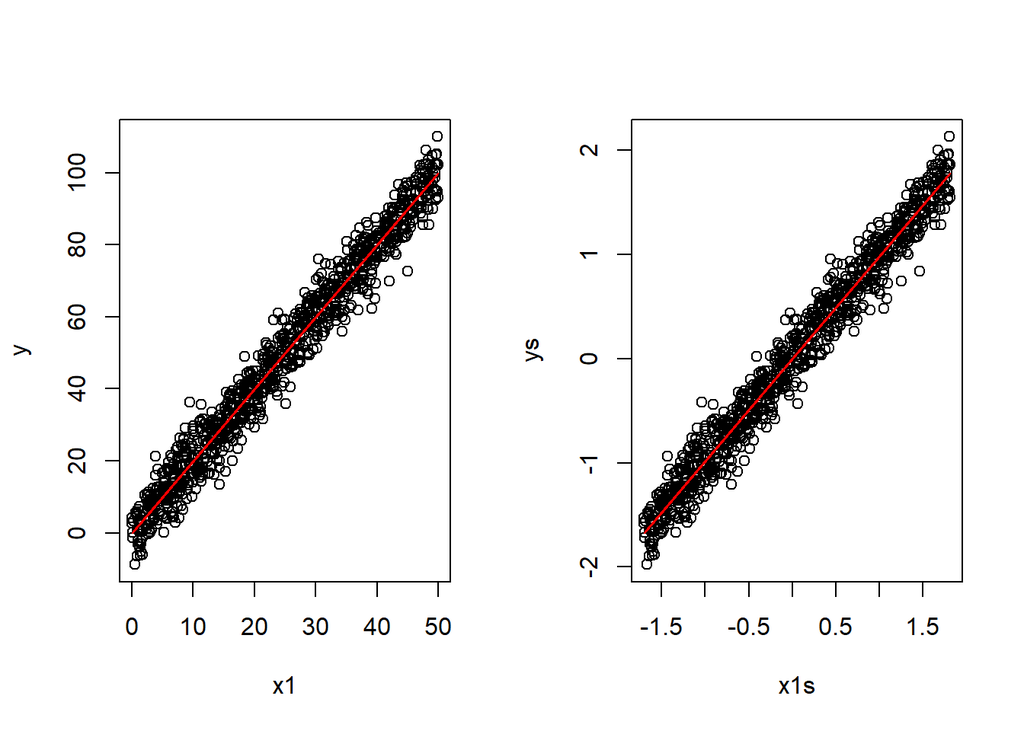

```r
plot(x1s, ys)
lines(x1s, predict(lm2), col = "red")
```

Coefficient for the scaled variables is different.

### Simulate and scale for Logistic regression

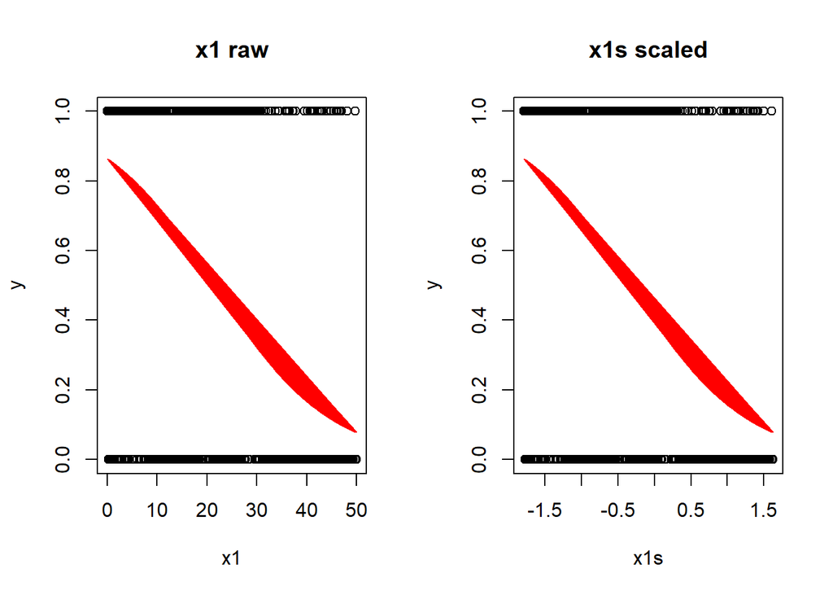

```r
x1 <- runif(1000, 0, 50)
y <- sapply(x1, function(x) ifelse(x < 30, rbinom(1, 1, prob=0.7), rbinom(1, 1, prob=0.1)) )

par(mfrow=c(1,2))
plot(x1, y, main= "x1 raw")


glm1 <- glm(y ~x1, family = binomial)
# summary(glm1)

# add glm1 to plot above
lines(x1, predict(glm1, type = "response"), col = "red")


# scale x1

x1s <- scale(x1)
# summary(x1s)

glm2 <- glm(y ~ x1s, family = binomial)
# summary(glm2)

plot(x1s, y, main ="x1s scaled")
lines(x1s, predict(glm2, type = "response"), col = "red")
```

```r
# raw covariate
summary(x1)
```

```
##     Min.  1st Qu.   Median     Mean  3rd Qu.     Max.
##  0.01228 13.69294 26.97453 26.21586 39.38097 49.97105
```

```r
# scaled covariate
summary(x1s)
```

```
##        V1
##  Min.   :-1.79129
##  1st Qu.:-0.85607
##  Median : 0.05186
##  Mean   : 0.00000
##  3rd Qu.: 0.89998
##  Max.   : 1.62392
```

In Logistic Regression, scaling the Covariate changes the coefficients.

```r
# coefficients differ!
coef(glm1)
```

```
## (Intercept)          x1
##  1.84983990 -0.08634462
```

```r
coef(glm2)
```

```
## (Intercept)         x1s
##  -0.4137585  -1.2630753
```

### Simulate for Colr

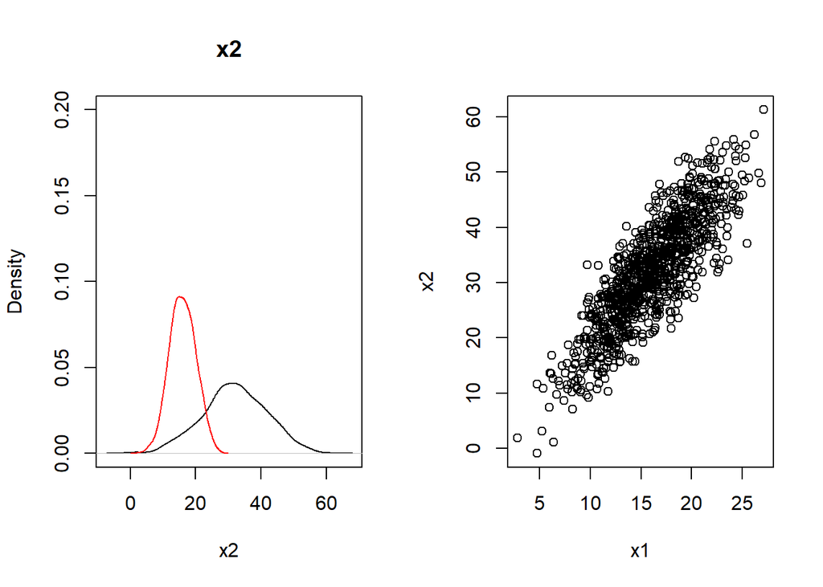

```r
x1 <- rnorm(1000, 16, 4)
x2 <- x1 * (2) + rnorm(1000, 0, 5)

# summary(x1)
# summary(x2)

par(mfrow = c(1,2))

# plot densities
plot(density(x2), main = "x2", xlab = "x2", ylab = "Density",  ylim = c(0, 0.2))
lines(density(x1), col = "red")

plot(x1, x2)
```

Standardize samples:

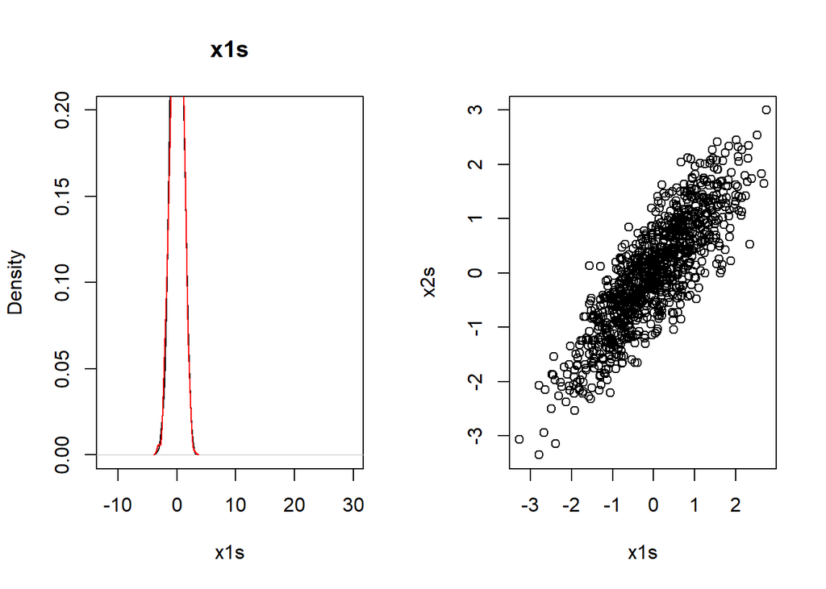

```r
x1s <- (x1 - mean(x1)) / sd(x1)
x2s <- (x2 - mean(x2)) / sd(x2)

# summary(x1s)
# summary(x2s)

par(mfrow=c(1,2))
# plot densities
plot(density(x1s), main = "x1s", xlab = "x1s", ylab = "Density", xlim = c(-12, 30), ylim = c(0, 0.2))
lines(density(x2s), col = "red")

plot(x1s, x2s)
```

```r
fit_raw <- Colr(x2 ~ x1, order=len_theta)
coef(fit_raw)
```

```
##        x1
## -0.691362
```

```r
fit_x2_std <- Colr(x2s ~ x1, order=len_theta)
coef(fit_x2_std)
```

```
##         x1
## -0.6915462
```

```r
fit_std <- Colr(x2s ~ x1s, order=len_theta)
coef(fit_std)
```

```
##      x1s
## -2.79444
```

```r
fit_x2_raw <- Colr(x2 ~ x1s, order=len_theta)
coef(fit_x2_raw)
```

```
##      x1s
## -2.79711
```

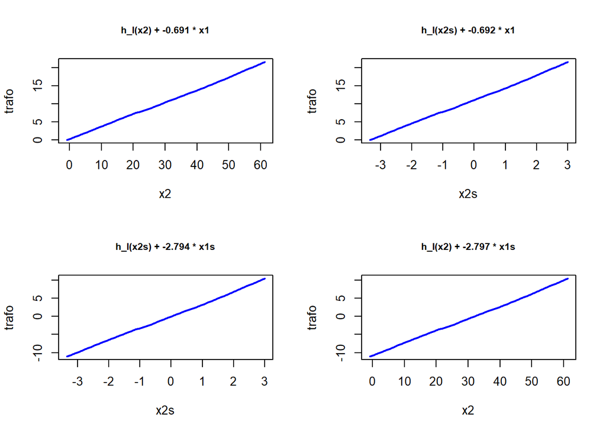

```r
# plot baseline trafo

par(mfrow=c(2,2))
temp = model.frame(fit_raw)[1:2,-1, drop=FALSE]
plot(fit_raw, which = 'baseline only', newdata = temp, lwd=2, col='blue',
     main=paste0("h_I(x2) + ", round(coef(fit_raw)[1], 3), " * x1"), cex.main=0.8)
temp = model.frame(fit_x2_std)[1:2,-1, drop=FALSE]
plot(fit_x2_std, which = 'baseline only', newdata = temp, lwd=2, col='blue',
     main=paste0("h_I(x2s) + ", round(coef(fit_x2_std)[1], 3), " * x1"), cex.main=0.8)
temp = model.frame(fit_std)[1:2,-1, drop=FALSE]
plot(fit_std, which = 'baseline only', newdata = temp, lwd=2, col='blue',
     main=paste0("h_I(x2s) + ", round(coef(fit_std)[1], 3), " * x1s"), cex.main=0.8)
temp = model.frame(fit_x2_raw)[1:2,-1, drop=FALSE]
plot(fit_x2_raw, which = 'baseline only', newdata = temp, lwd=2, col='blue',
     main=paste0("h_I(x2) + ", round(coef(fit_x2_raw)[1], 3), " * x1s"), cex.main=0.8)
```